# Import Libraries

```python
import pandas as pd
import numpy as np
import matplotlib.pyplot as plt
import seaborn as sns

from sklearn.model_selection import train_test_split
from sklearn.preprocessing import StandardScaler

import tensorflow as tf
from tensorflow import keras
from tensorflow.keras.models import Model
from tensorflow.keras.layers import Dense, Dropout, Flatten, Conv2D, MaxPooling2D, BatchNormalization, Input, concatenate
from tensorflow.keras.optimizers import Adam
from tensorflow.keras.callbacks import EarlyStopping, ModelCheckpoint
from tensorflow.keras.utils import plot_model
```

[output not shown]

# Import Dataset

```python
df = pd.read_csv('Dataset/Bank_Loan_Granting.csv')
df.head()
```

|  | ID | Age | Experience | Income | ZIP Code | Family | CCAvg | Education | Mortgage | Personal Loan | Securities Account | CD Account | Online | CreditCard |
| --- | --- | --- | --- | --- | --- | --- | --- | --- | --- | --- | --- | --- | --- | --- |
| 0 | 1 | 25 | 1 | 49 | 91107 | 4 | 1/60 | 1 | 0 | 0 | 1 | 0 | 0 | 0 |
| 1 | 2 | 45 | 19 | 34 | 90089 | 3 | 1/50 | 1 | 0 | 0 | 1 | 0 | 0 | 0 |
| 2 | 3 | 39 | 15 | 11 | 94720 | 1 | 1/00 | 1 | 0 | 0 | 0 | 0 | 0 | 0 |
| 3 | 4 | 35 | 9 | 100 | 94112 | 1 | 2/70 | 2 | 0 | 0 | 0 | 0 | 0 | 0 |
| 4 | 5 | 35 | 8 | 45 | 91330 | 4 | 1/00 | 2 | 0 | 0 | 0 | 0 | 0 | 1 |

# Fix Data Loading Errors and Deleting useless variable

```python
df.drop(columns=['ID'], axis=1, inplace=True)
```

Dropped because it is not useful for the model and unrelated to the target variable.

```python
# Change all / in CCAvg into . and change into double
df['CCAvg'] = df['CCAvg'].replace(to_replace=r'/', value='.', regex=True)
df['CCAvg'] = df['CCAvg'].astype(float)
```

Is done because the data inside in unrecognizable and seems to have a typo which is fixed by changing the '/' into '.' and making it a float

```python
df.head()
```

|  | Age | Experience | Income | ZIP Code | Family | CCAvg | Education | Mortgage | Personal Loan | Securities Account | CD Account | Online | CreditCard |
| --- | --- | --- | --- | --- | --- | --- | --- | --- | --- | --- | --- | --- | --- |
| 0 | 25 | 1 | 49 | 91107 | 4 | 1.6 | 1 | 0 | 0 | 1 | 0 | 0 | 0 |
| 1 | 45 | 19 | 34 | 90089 | 3 | 1.5 | 1 | 0 | 0 | 1 | 0 | 0 | 0 |
| 2 | 39 | 15 | 11 | 94720 | 1 | 1.0 | 1 | 0 | 0 | 0 | 0 | 0 | 0 |
| 3 | 35 | 9 | 100 | 94112 | 1 | 2.7 | 2 | 0 | 0 | 0 | 0 | 0 | 0 |
| 4 | 35 | 8 | 45 | 91330 | 4 | 1.0 | 2 | 0 | 0 | 0 | 0 | 0 | 1 |

# Data Exploration

```python
df.info()
```

```
<class 'pandas.core.frame.DataFrame'>
RangeIndex: 5000 entries, 0 to 4999
Data columns (total 13 columns):
 #   Column              Non-Null Count  Dtype
---  ------              --------------  -----
 0   Age                 5000 non-null   int64
 1   Experience          5000 non-null   int64
 2   Income              5000 non-null   int64
 3   ZIP Code            5000 non-null   int64
 4   Family              5000 non-null   int64
 5   CCAvg               5000 non-null   float64
 6   Education           5000 non-null   int64
 7   Mortgage            5000 non-null   int64
 8   Personal Loan       5000 non-null   int64
 9   Securities Account  5000 non-null   int64
 10  CD Account          5000 non-null   int64
 11  Online              5000 non-null   int64
 12  CreditCard          5000 non-null   int64
dtypes: float64(1), int64(12)
memory usage: 507.9 KB
```

```python
df.isnull().sum()
```

```
Age                   0
Experience            0
Income                0
ZIP Code              0
Family                0
CCAvg                 0
Education             0
Mortgage              0
Personal Loan         0
Securities Account    0
CD Account            0
Online                0
CreditCard            0
dtype: int64
```

The dataset has no NULL or NA values

## Check for Imbalance

### Customer Information (Age, Experience, ZIP Code, Family, Education, Income)

```python
customerInfo = ['Age', 'Experience', 'ZIP Code', 'Family', 'Education', 'Income']
```

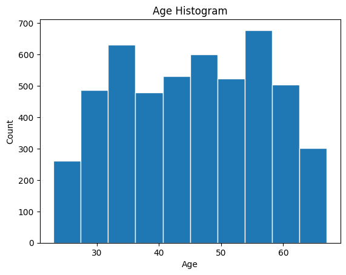

```
count    5000.000000
mean       45.338400
std        11.463166
min        23.000000
25%        35.000000
50%        45.000000
75%        55.000000
max        67.000000
Name: Age, dtype: float64
```

```python
plt.hist(df['Age'], edgecolor='white')
plt.title('Age Histogram')
plt.xlabel('Age')
plt.ylabel('Count')
plt.show()

df['Age'].describe()
```

The Age distribution is similar to a multimodal distribution with the average being 45.339 and standart deviation being 11.463. With the peaks at approximately 35 and 55 Years.

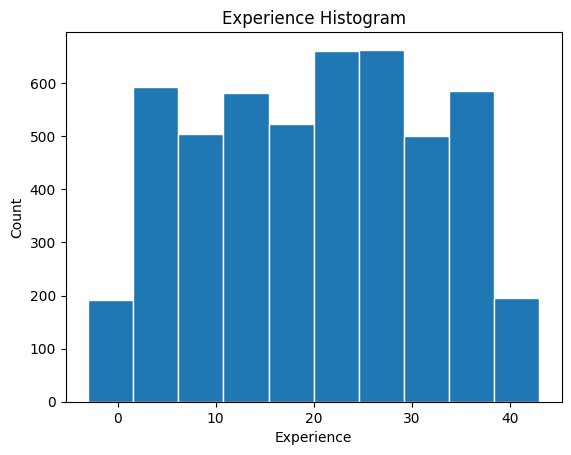

```
count    5000.000000
mean       20.104600
std        11.467954
min        -3.000000
25%        10.000000
50%        20.000000
75%        30.000000
max        43.000000
Name: Experience, dtype: float64
```

```python
plt.hist(df['Experience'], edgecolor='white')
plt.title('Experience Histogram')
plt.xlabel('Experience')
plt.ylabel('Count')
plt.show()

df['Experience'].describe()
```

The Experience distribution is similar to a multimodal distribution with the average being 20.105 and standart deviation being 11.468. With the peaks at approximately at 20 to 30 Years.

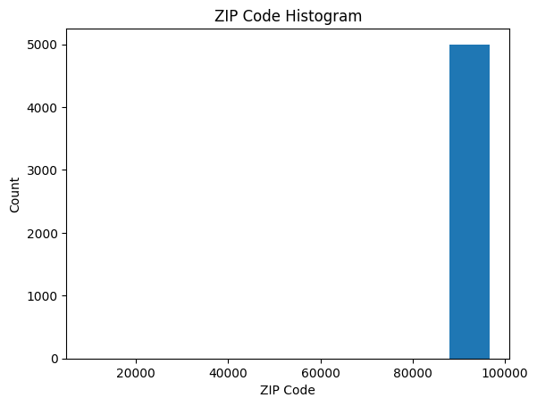

```
count     5000.000000
mean     93152.503000
std       2121.852197
min       9307.000000
25%      91911.000000
50%      93437.000000
75%      94608.000000
max      96651.000000
Name: ZIP Code, dtype: float64
```

```python
plt.hist(df['ZIP Code'])
plt.title('ZIP Code Histogram')
plt.xlabel('ZIP Code')
plt.ylabel('Count')
plt.show()

df['ZIP Code'].describe()
```

The ZIP Code has no clear distribution with the mean being 93152.4 and the standart deviation being 2121.85. Which could be dropped because it can cause underfitting.

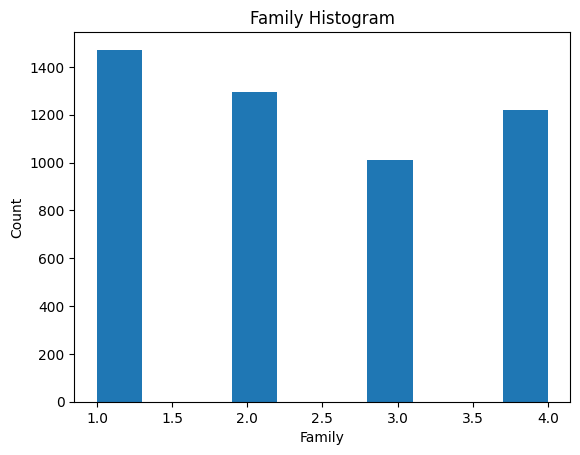

```python
plt.hist(df['Family'])
plt.title('Family Histogram')
plt.xlabel('Family')
plt.ylabel('Count')
plt.show()
```

The Family is evenly distributed between 1 to 4 with the majority being 1 Family Members, Followed with 2, 4, and 3 Family members subsequently.

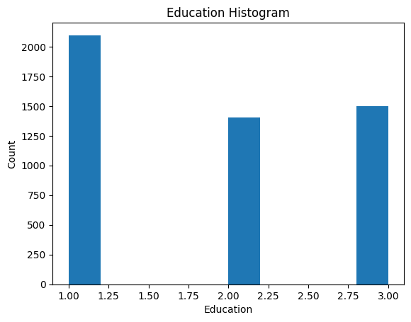

```python
plt.hist(df['Education'])
plt.title('Education Histogram')
plt.xlabel('Education')
plt.ylabel('Count')
plt.show()
```

The Education is evenly distributed between 1 to 3 with the majority being 1 (Undergraduate) followed with 3 (Advanced) and 2 (Graduate) Degree subsequently.

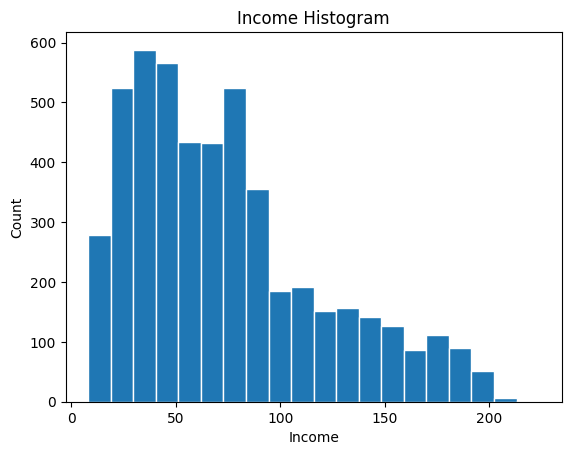

```
count    5000.000000
mean       73.774200
std        46.033729
min         8.000000
25%        39.000000
50%        64.000000
75%        98.000000
max       224.000000
Name: Income, dtype: float64
```

```python
plt.hist(df['Income'], edgecolor='white', bins=20)
plt.title('Income Histogram')
plt.xlabel('Income')
plt.ylabel('Count')
plt.show()

df['Income'].describe()
```

The Income Histogram is Right skewed with the peak being approximately around 0 to 50k but with a long tail of customer making high incomes. With it having Average of 73.774 and Standart Deviation of 46.034. This may an indication to do normalization to the data.

### Customer Behavior (CCAvg, Mortgage, Personal Loan, Securities Account, CD Account, Online, CreditCard)

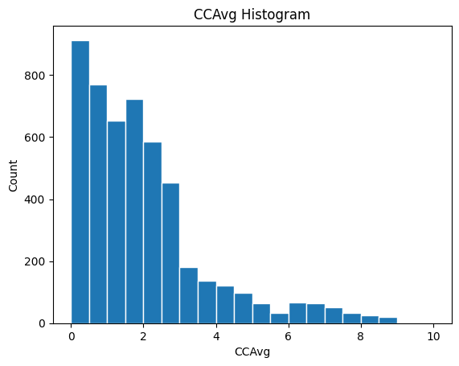

```
count    5000.000000
mean        1.937938
std         1.747659
min         0.000000
25%         0.700000
50%         1.500000
75%         2.500000
max        10.000000
Name: CCAvg, dtype: float64
```

```python
plt.hist(df['CCAvg'], edgecolor='white', bins=20)
plt.title('CCAvg Histogram')
plt.xlabel('CCAvg')
plt.ylabel('Count')
plt.show()

df['CCAvg'].describe()
```

The Credit Card Average Spending Histogram is skewed to the right with the peak being 0 or no spending. With the average being 1.937 and standart deviation being 1.747. This may an indication to do normalization to the data.

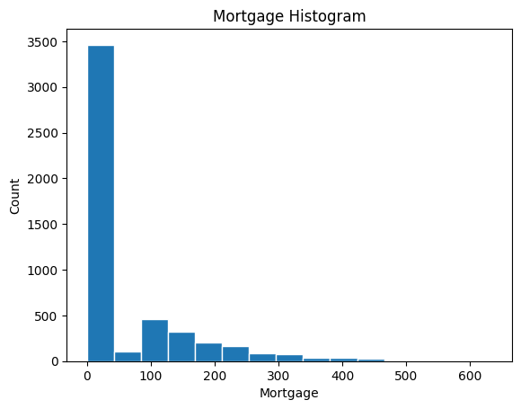

```
count    5000.000000
mean       56.498800
std       101.713802
min         0.000000
25%         0.000000
50%         0.000000
75%       101.000000
max       635.000000
Name: Mortgage, dtype: float64
```

```python
plt.hist(df['Mortgage'], edgecolor='white', bins = 15)
plt.title('Mortgage Histogram')
plt.xlabel('Mortgage')
plt.ylabel('Count')
plt.show()

df['Mortgage'].describe()
```

The Morgage Spending is around 0 and 100k on average with a long tail of higher mortgage spending. With the average being 56.5 and standart deviation being 101.7. This may an indication to do normalization to the data.

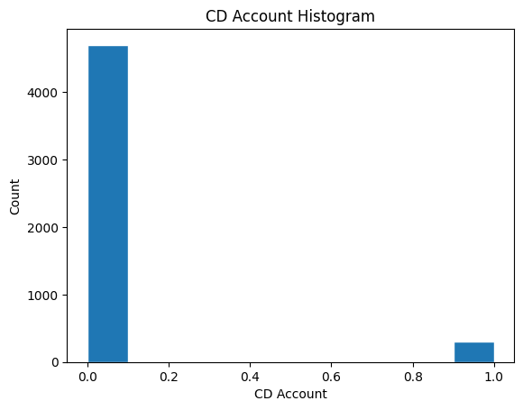

```
CD Account
0    0.9396
1    0.0604
Name: proportion, dtype: float64
```

```python
plt.hist(df['CD Account'], edgecolor='white')
plt.title('CD Account Histogram')
plt.xlabel('CD Account')
plt.ylabel('Count')
plt.show()

df['CD Account'].value_counts(normalize=True)
```

The CD Account Histogram shows that most customer doesn't have a Deposit(CD) Account with the proportion being 94% no Deposit account and 6% with Deposit Account

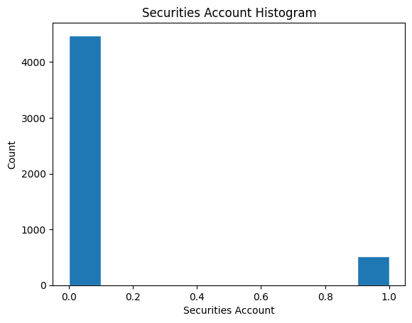

```
Securities Account
0    0.8956
1    0.1044
Name: proportion, dtype: float64
```

```python
plt.hist(df['Securities Account'], edgecolor='white')
plt.title('Securities Account Histogram')
plt.xlabel('Securities Account')
plt.ylabel('Count')
plt.show()

df['Securities Account'].value_counts(normalize=True)
```

The Securities account Histogram shows that most customer doesn't have a Securities Account with the proportion being 90% no Securities account and 10% with Securities Account

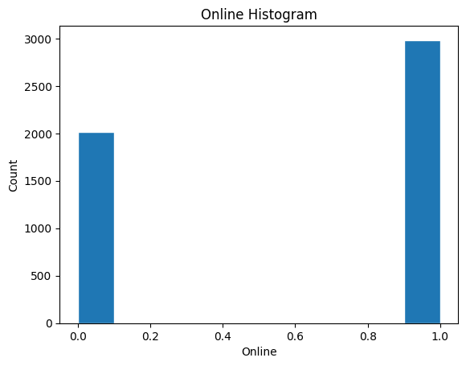

```
Online
1    0.5968
0    0.4032
Name: proportion, dtype: float64
```

```python
plt.hist(df['Online'], edgecolor='white')
plt.title('Online Histogram')
plt.xlabel('Online')
plt.ylabel('Count')
plt.show()

df['Online'].value_counts(normalize=True)
```

The Online Account Histogram shows that most customer have an Online Account with the proportion being 60% with Online Account and 40% without Online Account

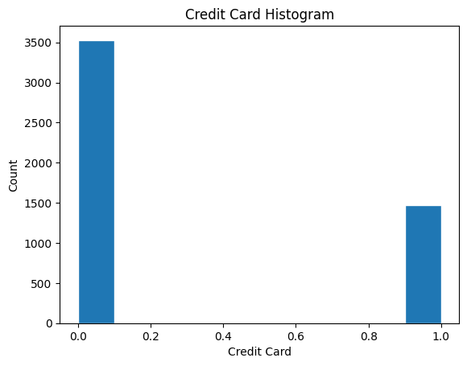

```
CreditCard
0    0.706
1    0.294
Name: proportion, dtype: float64
```

```python
plt.hist(df['CreditCard'], edgecolor='white')
plt.title('Credit Card Histogram')
plt.xlabel('Credit Card')
plt.ylabel('Count')
plt.show()

df['CreditCard'].value_counts(normalize=True)
```

The Credit Card Histogram shows that most customer doesn't have a Credit Card with the proportion being 70% no Credit Card and 30% with Credit Card

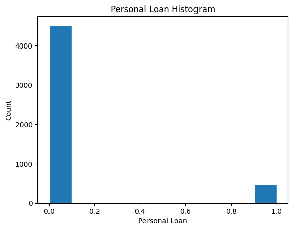

```
Personal Loan
0    0.904
1    0.096
Name: proportion, dtype: float64
```

```python
plt.hist(df['Personal Loan'], edgecolor='white')
plt.title('Personal Loan Histogram')
plt.xlabel('Personal Loan')
plt.ylabel('Count')
plt.show()

df['Personal Loan'].value_counts(normalize=True)
```

The Personal Loan Histogram shows that most customer doesn't have a Personal Loan with the proportion being 90% no Personal Loan and 10% with Personal Loan. This indicates that the dataset is imbalanced.

## Check Correlation

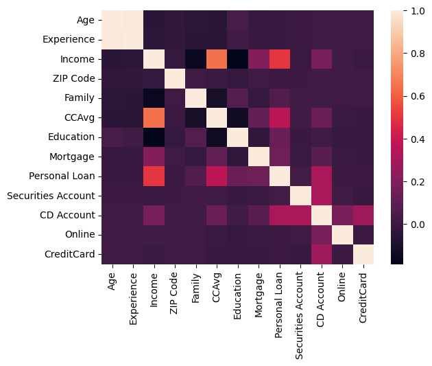

```python
sns.heatmap(df.corr())
```

From the heatmap we can see that

- Age and Experience is highly correlated (Could lead to multicolinearity)
- Personal Loan is Highly corelated to Income, CCAvg, and CD Account and somewhat correlated with Mortgage, Education, and Number of Family Members with it having little to no corelation with CreditCard, Online, Securities Account, ZIP Code, Experience, and Age

# 1.c Problem in the dataset

The Problem in the dataset is:

- The Existence of Multicolinearity between Age and Experience
- The Existence of Imbalance in the Personal Loan Target Variable (90% No Personal Loan and 10% Yes Personal Loan)
- The Existence of Unnecessary Variable (ZIP Code)
- The Existence of Outliers in the Income, CCAvg, and Mortgage Variable shown by the long tail in the histogram
- Some data is uncorelated to the target variable (CreditCard, Online, Securities Account, ZIP Code, Experience, and Age)

# 1.a Preprocessing

What we will do:

## Dropping uncorrelated variable

```python
newDf = df.drop(columns=['CreditCard', 'Online', 'Securities Account', 'ZIP Code', 'Experience', 'Age'], axis=1)
```

```python
newDf.head()
```

|  | Income | Family | CCAvg | Education | Mortgage | Personal Loan | CD Account |
| --- | --- | --- | --- | --- | --- | --- | --- |
| 0 | 49 | 4 | 1.6 | 1 | 0 | 0 | 0 |
| 1 | 34 | 3 | 1.5 | 1 | 0 | 0 | 0 |
| 2 | 11 | 1 | 1.0 | 1 | 0 | 0 | 0 |
| 3 | 100 | 1 | 2.7 | 2 | 0 | 0 | 0 |
| 4 | 45 | 4 | 1.0 | 2 | 0 | 0 | 0 |

## Spliting Data

```python
X, y = newDf.drop(columns=['Personal Loan'], axis=1), newDf['Personal Loan']

X_train, X_val_test, y_train, y_val_test = train_test_split(X, y, test_size=0.2, random_state=42)
X_val, X_test, y_val, y_test = train_test_split(X_val_test, y_val_test, test_size=0.5, random_state=42)
```

## Normalization

```python
scaler = StandardScaler()
```

### Train dataset

```python
scaled_x_train = X_train.drop(columns=['Family', 'Education', 'CD Account'])
scaled_x_train = scaler.fit_transform(scaled_x_train)

X_train = pd.concat([pd.DataFrame(scaled_x_train), X_train.drop(columns=['Mortgage', 'CD Account', 'Income'], axis=1).reset_index(drop=True)], axis=1)
```

```python
X_train.info()
```

```
<class 'pandas.core.frame.DataFrame'>
RangeIndex: 4000 entries, 0 to 3999
Data columns (total 6 columns):
 #   Column     Non-Null Count  Dtype
---  ------     --------------  -----
 0   0          4000 non-null   float64
 1   1          4000 non-null   float64
 2   2          4000 non-null   float64
 3   Family     4000 non-null   int64
 4   CCAvg      4000 non-null   float64
 5   Education  4000 non-null   int64
dtypes: float64(4), int64(2)
memory usage: 187.6 KB
```

### Valid dataset

```python
scaled_x_val = X_val.drop(columns=['Family', 'Education', 'CD Account'])
scaled_x_val = scaler.transform(scaled_x_val)

X_val = pd.concat([pd.DataFrame(scaled_x_val), X_val.drop(columns=['Mortgage', 'CD Account', 'Income'], axis=1).reset_index(drop=True)], axis=1)
```

### Test dataset

```python
scaled_x_test = X_test.drop(columns=['Family', 'Education', 'CD Account'])
scaled_x_test = scaler.transform(scaled_x_test)

X_test = pd.concat([pd.DataFrame(scaled_x_test), X_test.drop(columns=['Mortgage', 'CD Account', 'Income'], axis=1).reset_index(drop=True)], axis=1)
```

## Create Tensor Dataset

```python
train_ds = tf.data.Dataset.from_tensor_slices((X_train, y_train)).batch(32)
test_ds = tf.data.Dataset.from_tensor_slices((X_test, y_test)).batch(32)
val_ds = tf.data.Dataset.from_tensor_slices((X_val, y_val)).batch(32)
```

[output not shown]

# 1.d

## Modelling

```python
inputs = tf.keras.Input(shape=(6,))
dense1 = Dense(12, activation='relu')(inputs)
dense2 = Dense(12, activation='relu')(dense1)
outputs = Dense(1, activation='sigmoid')(dense2)

model1 = Model(inputs=inputs, outputs=outputs)
model1.summary()
```

```
Model: "model"
_________________________________________________________________
 Layer (type)                Output Shape              Param #
=================================================================
 input_1 (InputLayer)        [(None, 6)]               0

 dense (Dense)               (None, 12)                84

 dense_1 (Dense)             (None, 12)                156

 dense_2 (Dense)             (None, 1)                 13

=================================================================
Total params: 253 (1012.00 Byte)
Trainable params: 253 (1012.00 Byte)
Non-trainable params: 0 (0.00 Byte)
_________________________________________________________________
```

```python
model1.compile(loss='binary_crossentropy', optimizer=tf.keras.optimizers.Adam(), metrics=tf.keras.metrics.Precision())
```

```python
my_callbacks = [
    tf.keras.callbacks.EarlyStopping(monitor='val_loss', patience=3, mode='auto') # Stop training when `val_loss` is no longer improving in 3 epochs
]

history = model1.fit(train_ds, validation_data=val_ds, epochs=100, callbacks=my_callbacks)
```

[output not shown]

## Model Evaluation

```python
model1.evaluate(test_ds)
```

```
[0.06561530381441116, 0.9487179517745972]
```

```python
from sklearn.metrics import classification_report

y_pred = model1.predict(X_test)
predicted = tf.squeeze(y_pred)
predicted = np.array([1 if x >= 0.5 else 0 for x in predicted])

print(classification_report(y_test, predicted))
```

```
              precision    recall  f1-score   support

           0       0.98      1.00      0.99       453
           1       0.95      0.79      0.86        47

    accuracy                           0.98       500
   macro avg       0.96      0.89      0.92       500
weighted avg       0.98      0.98      0.97       500
```

# 1.e

Because the 1st model is already such a good fit for the dataset, we will proceed using the 1st model without any changes to the model and hyperparameter tuning. But it seem that 100 epoch is not enough for the model to train complete ly, we will increase the epoch to 500 to see if the model can improve further.

```python
inputs = tf.keras.Input(shape=(6,))
dense1 = Dense(12, activation='relu')(inputs)
dense2 = Dense(12, activation='relu')(dense1)
outputs = Dense(1, activation='sigmoid')(dense2)

model2 = Model(inputs=inputs, outputs=outputs)
model2.summary()
```

```
Model: "model_1"
_________________________________________________________________
 Layer (type)                Output Shape              Param #
=================================================================
 input_2 (InputLayer)        [(None, 6)]               0

 dense_3 (Dense)             (None, 12)                84

 dense_4 (Dense)             (None, 12)                156

 dense_5 (Dense)             (None, 1)                 13

=================================================================
Total params: 253 (1012.00 Byte)
Trainable params: 253 (1012.00 Byte)
Non-trainable params: 0 (0.00 Byte)
_________________________________________________________________
```

```python
model2.compile(loss='binary_crossentropy', optimizer=tf.keras.optimizers.Adam(), metrics=tf.keras.metrics.Precision())
```

```python
my_callbacks = [
    tf.keras.callbacks.EarlyStopping(monitor='val_loss', patience=3, mode='auto') # Stop training when `val_loss` is no longer improving in 3 epochs
]

history = model2.fit(train_ds, validation_data=val_ds, epochs=500, callbacks=my_callbacks)
```

# 1.f

```python
model2.evaluate(test_ds)
```

```
[0.05803532898426056, 1.0]
```

```python
from sklearn.metrics import classification_report

y_pred = model2.predict(X_test)
predicted = tf.squeeze(y_pred)
predicted = np.array([1 if x >= 0.5 else 0 for x in predicted])

print(classification_report(y_test, predicted))
```

```
              precision    recall  f1-score   support

           0       0.98      1.00      0.99       453
           1       1.00      0.83      0.91        47

    accuracy                           0.98       500
   macro avg       0.99      0.91      0.95       500
weighted avg       0.98      0.98      0.98       500
```

After changing the epoch count and retraining the model, we have gotten a precision of 1, recall of 0.83, and f1 score of 0.91. This meant that the model can predict the positive class with a precision of 100% and recall of 83% with an aggregate f1 score of 91%. This is a good result for the model.

```python
model2.save_weights('model2.h5')
```